# COMPSCIX 415.2 Homework 2

Elizabeth Eldridge

February 12, 2019

```r
knitr::opts_chunk$set(echo = TRUE, message=FALSE, warning=FALSE)
```

## Section 3.2.4: all exercises

```r
library(tidyverse)
nrow(mpg)
```

```
## [1] 234
```

```r
ncol(mpg)
```

```
## [1] 11
```

2. How many rows are in mpg? How many columns? MPG has 234 rows and 11 columns

```r
?mpg
```

3. What does the drv variable describe? Read the help for ?mpg to find out. The mpg help file tells us the drv variable describes the type of drive, for example front-wheel, rear-wheel, or 4-wheel

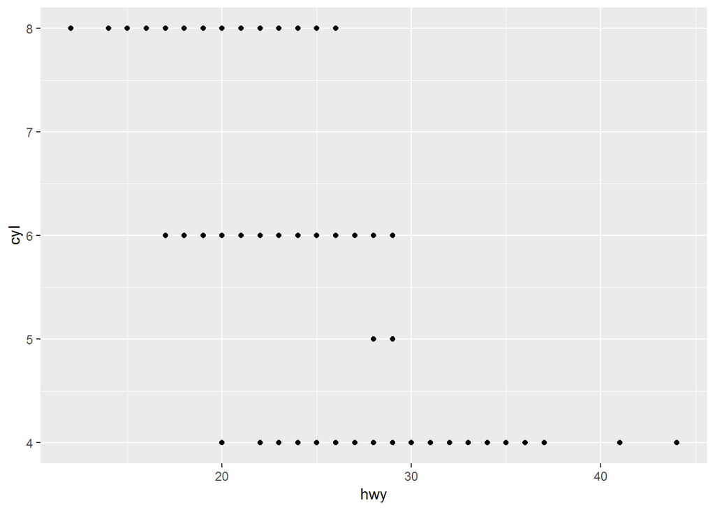

```r
ggplot(data = mpg) +
  geom_point(mapping = aes(x = hwy, y = cyl))
```

4. Make a scatterplot of hwy vs cyl.

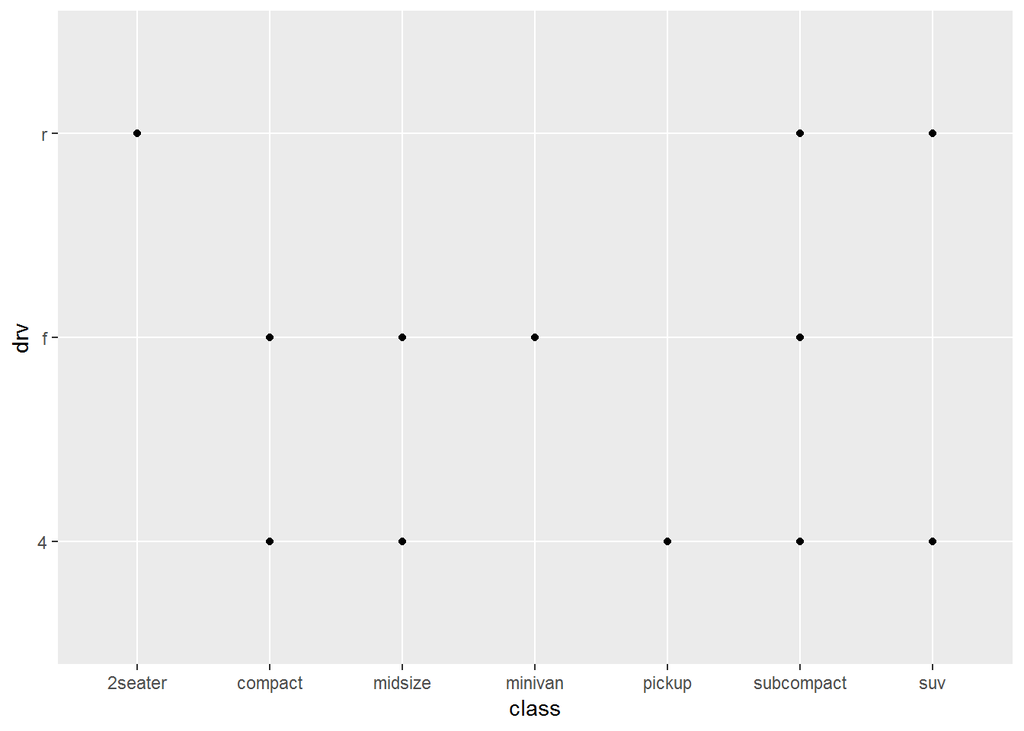

```r
ggplot(data = mpg) +
  geom_point(mapping = aes(x = class, y = drv))
```

5) What happens if you make a scatterplot of class vs drv? Why is the plot not useful? A scatterplot is not useful for this kind of correlation because there is no trend and the same classes of cars can have multiple different types of wheel-drives. In this example, a visual is not more useful than merely listing it out.

## Section 3.3.1: all exercises

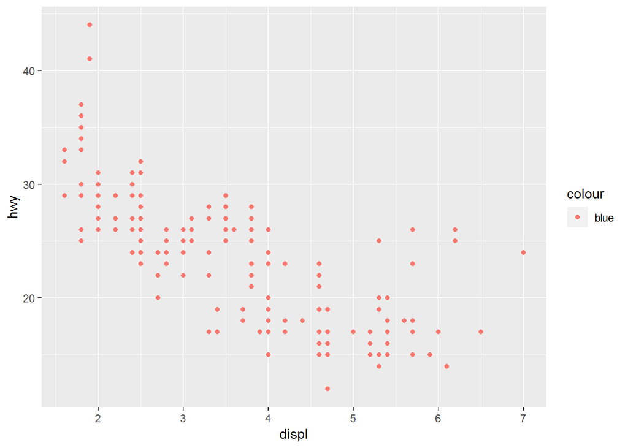

```r
ggplot(data = mpg) +
  geom_point(mapping = aes(x = displ, y = hwy, color = "blue"))
```

1. What’s gone wrong with this code? Why are the points not blue? The points are not blue in this code because the “Color” command needs to be outside of the aesthetic brackets, or else R will be expecting a variable name there

```r
data(mpg)
?mpg
head(mpg, 20)
```

```
## # A tibble: 20 x 11
##    manufacturer model displ  year   cyl trans drv     cty   hwy fl    class
##    <chr>        <chr> <dbl> <int> <int> <chr> <chr> <int> <int> <chr> <chr>
##  1 audi         a4      1.8  1999     4 auto~ f        18    29 p     comp~
##  2 audi         a4      1.8  1999     4 manu~ f        21    29 p     comp~
##  3 audi         a4      2    2008     4 manu~ f        20    31 p     comp~
##  4 audi         a4      2    2008     4 auto~ f        21    30 p     comp~
##  5 audi         a4      2.8  1999     6 auto~ f        16    26 p     comp~
##  6 audi         a4      2.8  1999     6 manu~ f        18    26 p     comp~
##  7 audi         a4      3.1  2008     6 auto~ f        18    27 p     comp~
##  8 audi         a4 q~   1.8  1999     4 manu~ 4        18    26 p     comp~
##  9 audi         a4 q~   1.8  1999     4 auto~ 4        16    25 p     comp~
## 10 audi         a4 q~   2    2008     4 manu~ 4        20    28 p     comp~
## 11 audi         a4 q~   2    2008     4 auto~ 4        19    27 p     comp~
## 12 audi         a4 q~   2.8  1999     6 auto~ 4        15    25 p     comp~
## 13 audi         a4 q~   2.8  1999     6 manu~ 4        17    25 p     comp~
## 14 audi         a4 q~   3.1  2008     6 auto~ 4        17    25 p     comp~
## 15 audi         a4 q~   3.1  2008     6 manu~ 4        15    25 p     comp~
## 16 audi         a6 q~   2.8  1999     6 auto~ 4        15    24 p     mids~
## 17 audi         a6 q~   3.1  2008     6 auto~ 4        17    25 p     mids~
## 18 audi         a6 q~   4.2  2008     8 auto~ 4        16    23 p     mids~
## 19 chevrolet    c150~   5.3  2008     8 auto~ r        14    20 r     suv
## 20 chevrolet    c150~   5.3  2008     8 auto~ r        11    15 e     suv
```

```r
#str(mpg) #"fatal error": Why does running this always make my R session abort??

sapply(mpg,class) #apply the class function to the dataset mpg
```

```
## manufacturer        model        displ         year          cyl
##  "character"  "character"    "numeric"    "integer"    "integer"
##        trans          drv          cty          hwy           fl
##  "character"  "character"    "integer"    "integer"  "character"
##        class
##  "character"
```

2. Which variables in mpg are categorical? Which variables are continuous? (Hint: type ?mpg to read the documentation for the dataset). How can you see this information when you run mpg?

The class, fl, drv, trans, model and manufacturer variables are categorical, with the displ, year, cyl, cty, and hwy variables being continuous. You can check this both by viewing the help page for MPG, the structure of MPG (str(mpg)) and/or by viewing the head of the dataset and comparing this sample with the description of variables from the help page. Applying the ‘class’ function to each column in the MPG dataset is another way to check the variable types.

3. Map a continuous variable to color, size, and shape. How do these aesthetics behave differently for categorical vs. continuous variables?

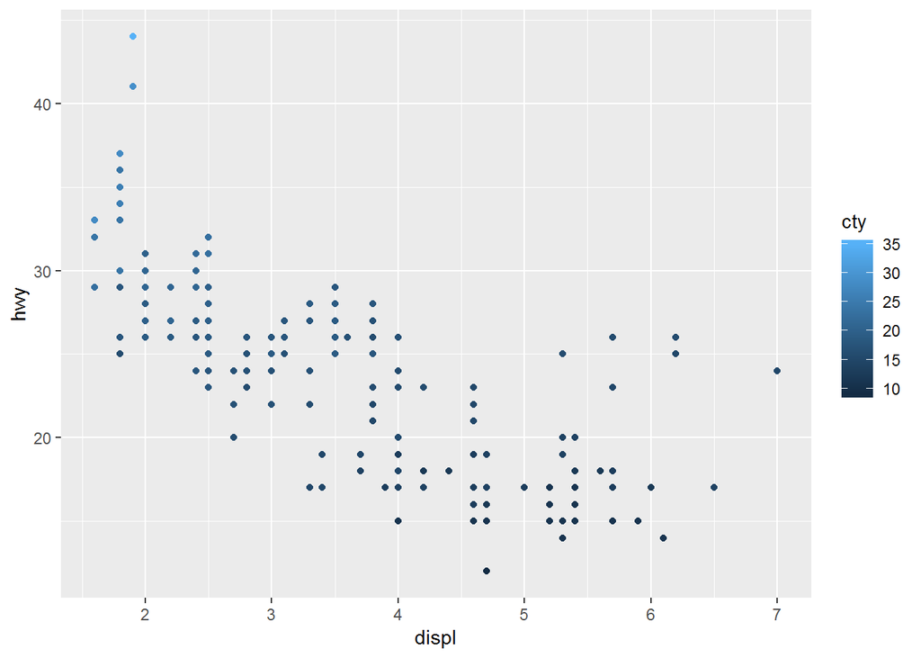

```r
#color + continuous
ggplot(data=mpg) + geom_point(mapping = aes(x = displ, y = hwy, color = cty))
```

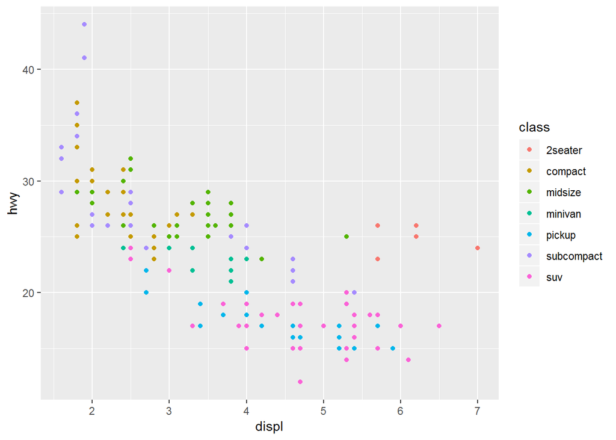

```r
#color + categorical
ggplot(data=mpg) + geom_point(mapping = aes(x = displ, y = hwy, color = class))
```

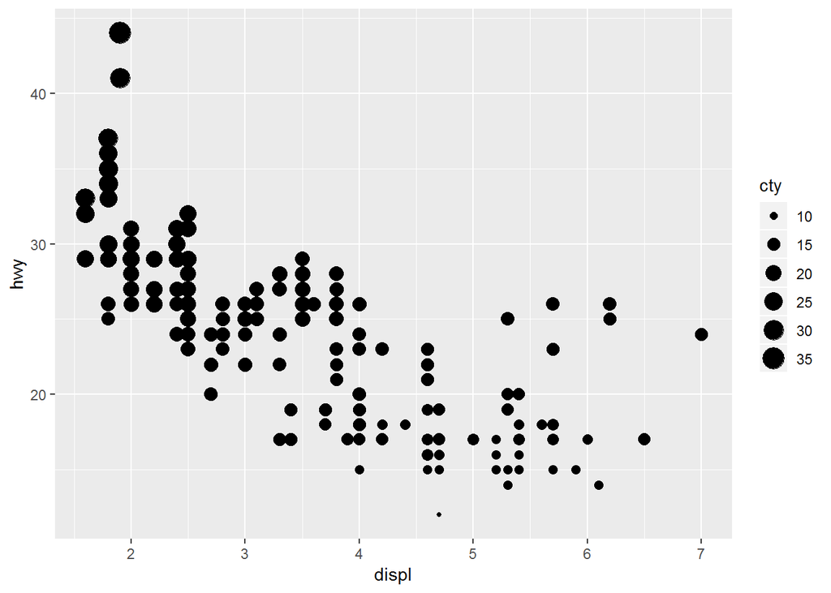

```r
#size + continuous
ggplot(data=mpg) + geom_point(mapping = aes(x = displ, y = hwy, size = cty))
```

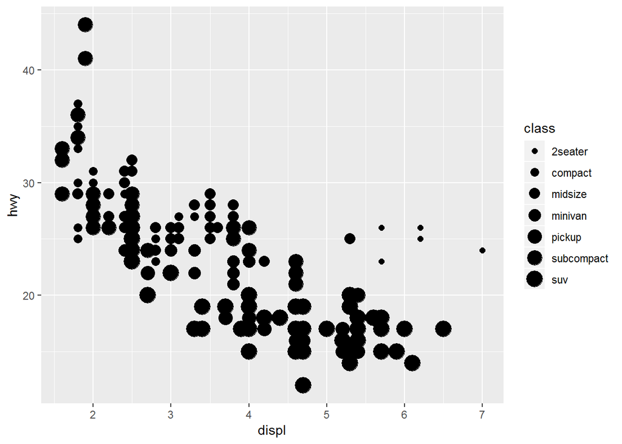

```r
#size + categorical
ggplot(data=mpg) + geom_point(mapping = aes(x = displ, y = hwy, size = class))
```

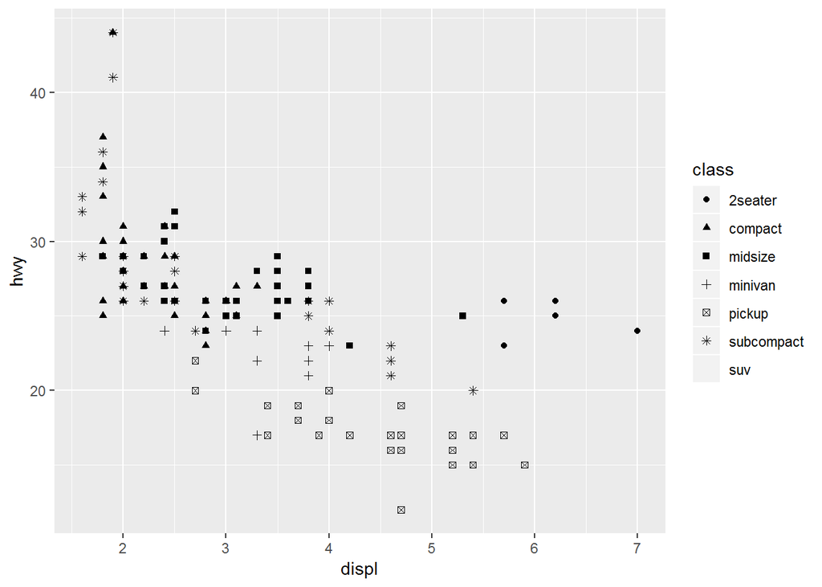

```r
#shape + continuous
#ggplot(data=mpg) + geom_point(mapping = aes(x = displ, y = hwy, shape = cty))
#shape + categorical
ggplot(data=mpg) + geom_point(mapping = aes(x = displ, y = hwy, shape = class))
```

For a continuous variable, mapping to color creates a nice gradient across values, though these are difficult to discern from each other. Color is easier to see for a categorical variable as the groups are much more visually distinct.

For the size aesthetic, R gives a warning that this is not advised for a categorical variable as there is no correlation between the category that is used and the size of the point; this aesthetic makes much more sense for a continuous variable where the size is correlated with the value of the variable.

R also gives an error noting the a continuous variable cannot be mapped to Shape, and that the shape palette cannot deal with more than 6 discrete categories, so probably best to only use teh shape aesthetic when dealing with a categorical variable with very few categories.

4. What happens if you map the same variable to multiple aesthetics?

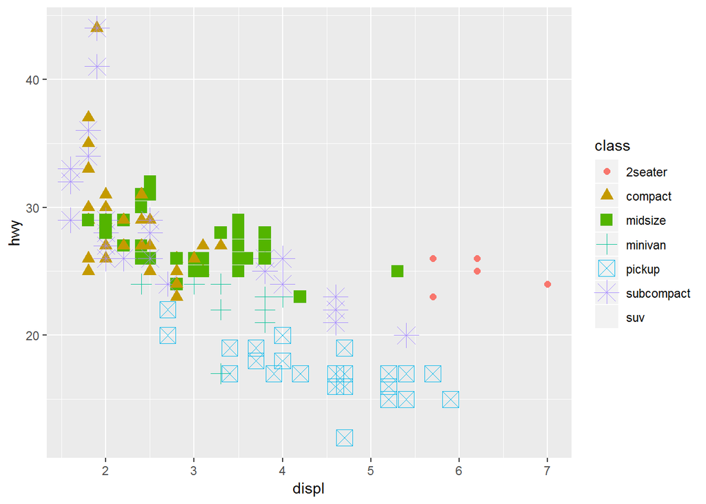

```r
#mapping a variable to multiple aesthetics
ggplot(data=mpg) + geom_point(mapping = aes(x = displ, y = hwy, color = class,
                                                                size = class,
                                                                shape = class))
```

Mapping the same variable to multiple aesthetics is possible if using the correct type of variable but becomes quite messy and with as many categories as the variable in the example above loses most of the meaning that these different aesthetics carry in the first place.

5. What does the stroke aesthetic do? What shapes does it work with? (Hint: use ?geom_point)

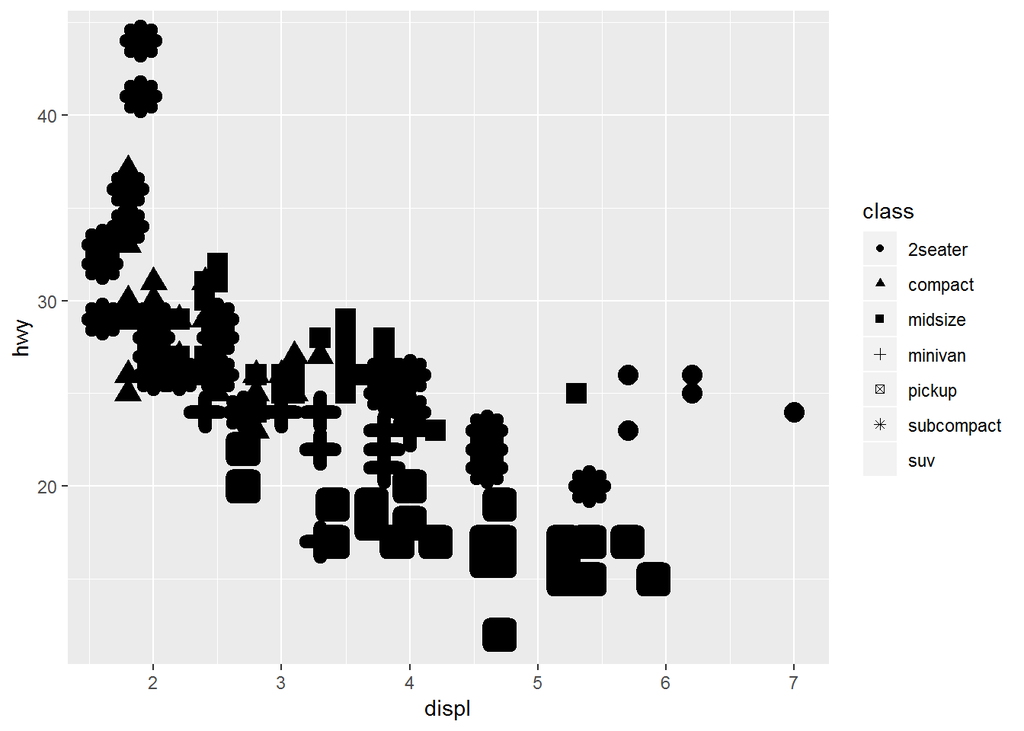

```r
?geom_point

ggplot(data=mpg) + geom_point(mapping = aes(x = displ, y = hwy, shape = class, stroke = 5))
```

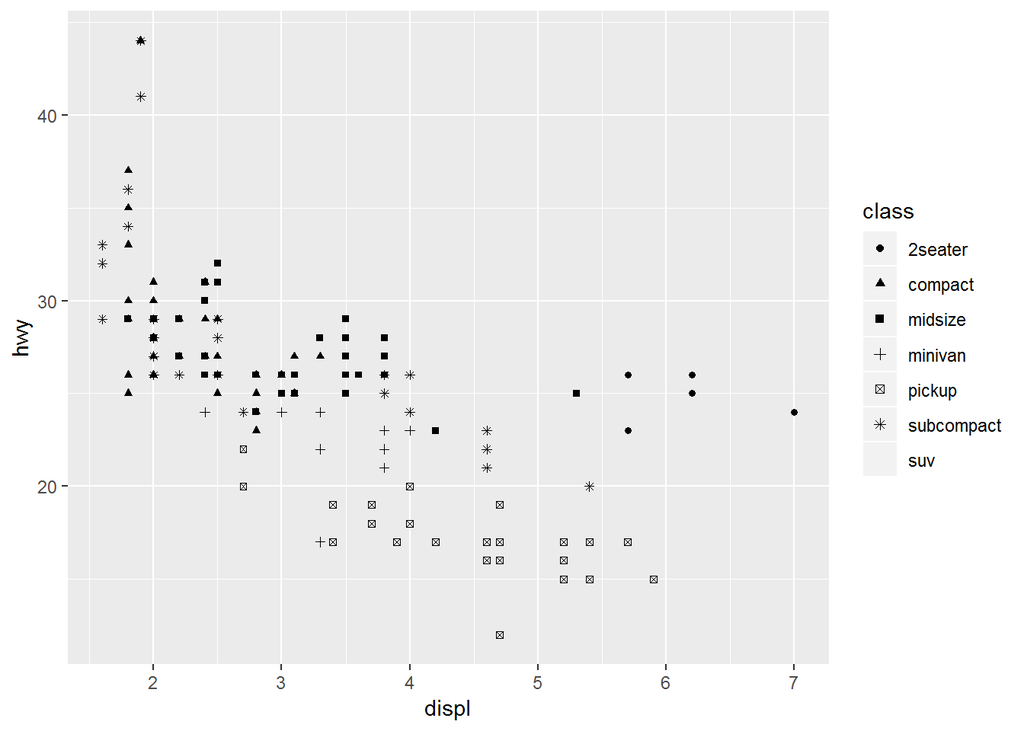

```r
ggplot(data=mpg) + geom_point(mapping = aes(x = displ, y = hwy, shape = class, stroke = .1))
```

The stroke aesthetic controls the size of the “brush stroke” and seems to work with all shapes in the shape aesthetic when used in geom_point.

6. What happens if you map an aesthetic to something other than a variable name, like aes(colour = displ < 5)? Note, you’ll also need to specify x and y.

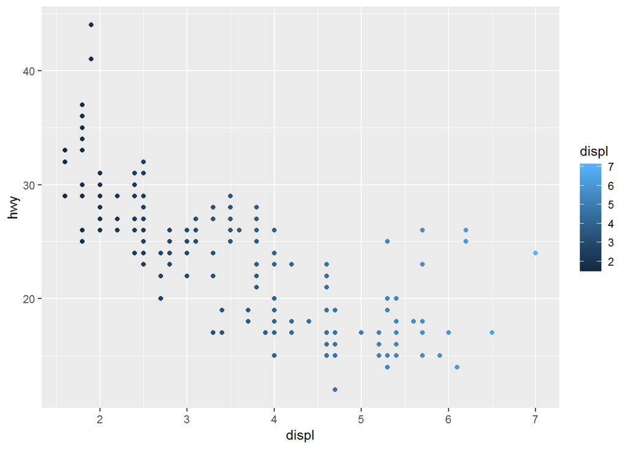

```r
ggplot(data=mpg) + geom_point(mapping = aes(x = displ, y = hwy, colour = displ))
```

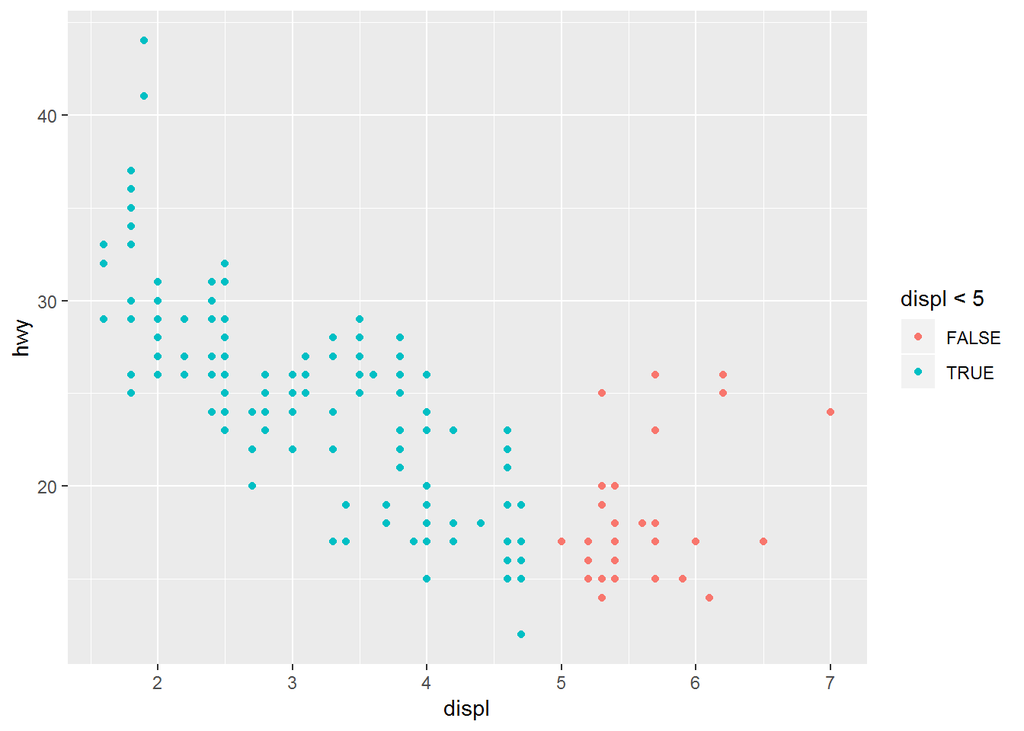

```r
ggplot(data=mpg) + geom_point(mapping = aes(x = displ, y = hwy, colour = displ < 5))
```

Mapping an aesthetic to something other than a variable name in this case creates a dichotomous outcome with one color for values below those of 5 in the ‘displ’ variable, and a different color for those values 5 or above.

## Section 3.5.1: #4 and #5 only

4.)Take the first faceted plot in this section:

ggplot(data = mpg) + geom_point(mapping = aes(x = displ, y = hwy)) + facet_wrap(~ class, nrow = 2)

What are the advantages to using faceting instead of the colour aesthetic? What are the disadvantages? How might the balance change if you had a larger dataset?

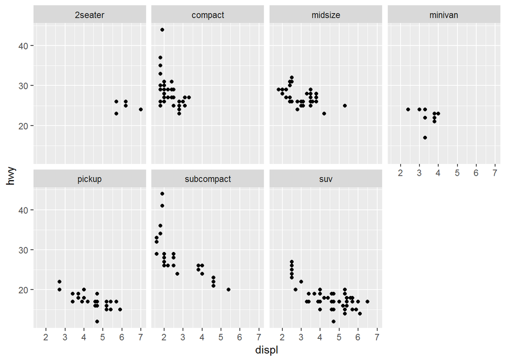

```r
ggplot(data = mpg) +
    geom_point(mapping = aes(x = displ, y = hwy)) +
    facet_wrap(~ class, nrow = 2)
```

Using faceting allows you to see really examine each facet uniquely which can be helpful without the distraction of all other data. However, using the colour asthetic could be useful if you are trying to examine these different facets in relation to one another. The balance might change more to favour faceting with a larger dataset given that the color aesthetic in a large dataset may create too much overlay of data points and too little distinction between colors.

5. Read ?facet_wrap. What does nrow do? What does ncol do? What other options control the layout of the individual panels? Why doesn’t facet_grid() have nrow and ncol arguments?

```r
?facet_wrap
```

facet_wrap makes a 1 dimensional sequence of panels into 2d where nrow defines the number of rows to use and ncol defines the number of columns to use for the facet. You can also choose to use fixed or free scale, control the labelling using ‘switch’ or ‘strip.position’, or use ‘as.table’ to make the layout of the table with the highest values at the bottom right, etc. Facet_grid() does not have this option because it forms a matrix of panels defined by the row and columns of the faceting variables.

## Section 3.6.1: #1-5.

1.) What geom would you use to draw a line chart? A boxplot? A histogram? An area chart?

I would use geom_abline() to draw a line chart, geom_boxplot() for a boxplot, geom_bar or stat_count() for a bar chart, and geom_area() for an area chart.

2.) Run this code in your head and predict what the output will look like. Then, run the code in R and check your predictions.

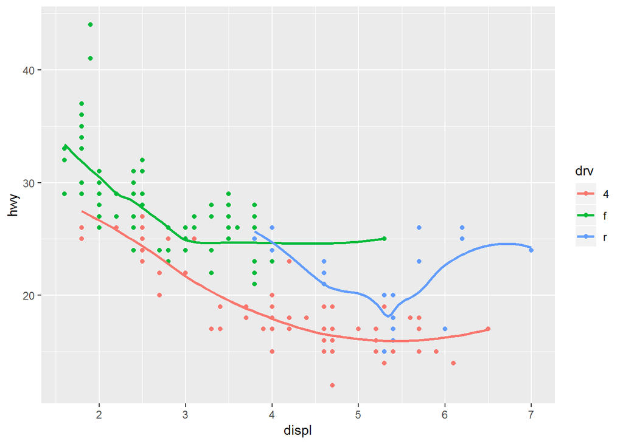

```r
 ggplot(data = mpg, mapping = aes(x = displ, y = hwy, color = drv)) +
  geom_point() +
  geom_smooth(se = FALSE)
```

3.)What does show.legend = FALSE do? What happens if you remove it? Why do you think I used it earlier in the chapter?

show.legend = FALSE will hide the legend, whereas the default is to include it. Hiding the legend, for example earlier in the chapter, can be useful for space purposes as well as if you are charting multiple different plots where the values of the legend will change across plots.

4.) What does the se argument to geom_smooth() do?

The argument of true or false following the ‘se’ argument tells it whether or not to display the confidence interval around the smooth curve created by geom_smooth().

5.) Will these two graphs look different? Why/why not?

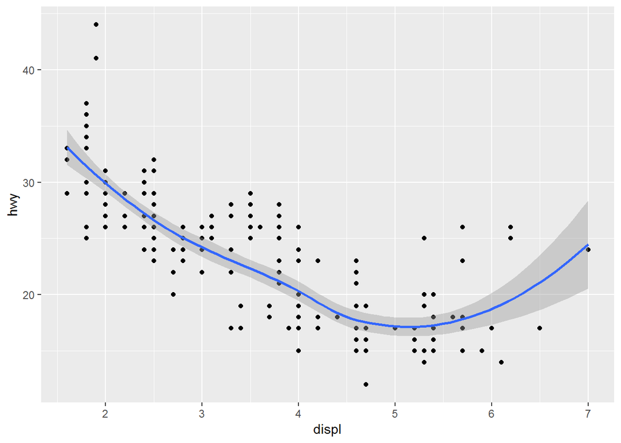

```r
    ggplot(data = mpg, mapping = aes(x = displ, y = hwy)) +
              geom_point() +
              geom_smooth()
```

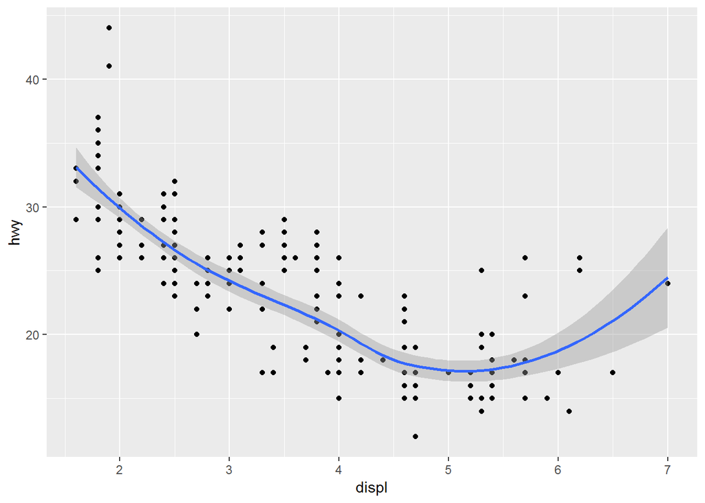

```r
    ggplot() +
      geom_point(data = mpg, mapping = aes(x = displ, y = hwy)) +
      geom_smooth(data = mpg, mapping = aes(x = displ, y = hwy))
```

No, these two plots will show the same thing because the exact same arguments are in the bottom statement as in the above- these are simply two different methods of creating the same output. If multiple ‘blank’ geoms are added to a plot they will take on the aesthetics defined in the ggplot() statement.

## Section 3.7.1: #2 only

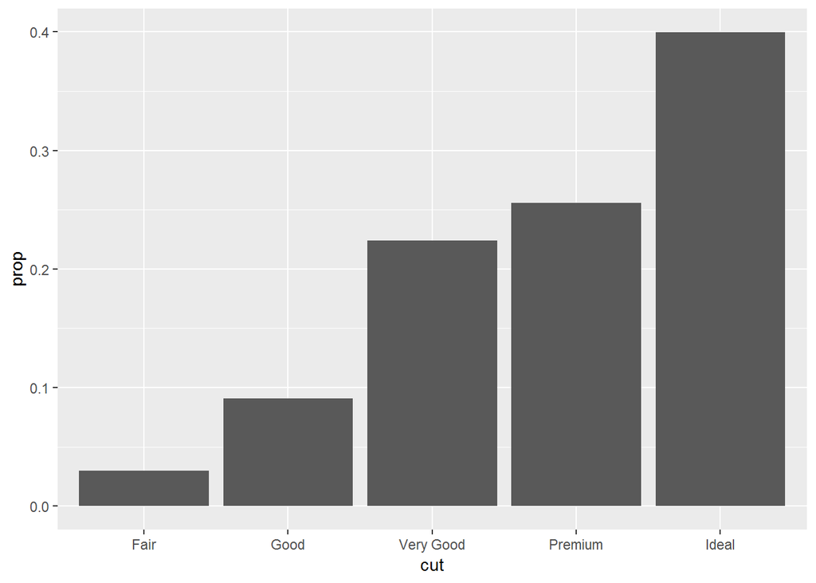

```r
ggplot(data = diamonds) +
  geom_bar(mapping = aes(x = cut, y = ..prop.., group = 1))
```

```r
?geom_bar
```

The ‘prop’ option will give you a y-axis of the stats by groupwise proportion and count option will give you number of points in each bin.